# A tutorial to select participants and create two balanced groups using propensity scores

Janet Y. Bang, Megha Sharda, and Aparna Nadig

last update: 31 May 2020

A template of this workflow can be downloaded [here](https://osf.io/6a3e4/).

All data and code for this workflow can be downloaded [here](https://github.com/janetybang/propensity_scores).

This tutorial follows the workflow below to select participants for matched groups (Bang, Sharda, & Nadig, in preparation). Please refer to Code buttons to show/hide code as desired.

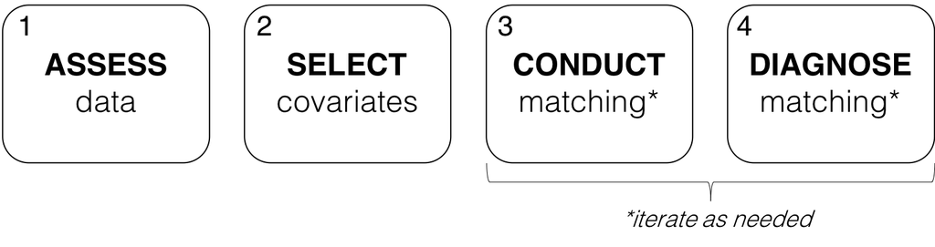

```r
include_graphics("diagram_4steps.png")
```

### Load libraries and set theme

```r
# load libraries
library(tidyverse)
library(MatchIt)
library(GGally)
library(compute.es)
library(compareGroups)
library(gridExtra)

# set theme to black and white
theme_set(theme_bw())
```

### Read in data

```r
# read in data
demo <- read_csv("./data/demographics.csv")
celf <- read_csv("./data/celf.csv")
leiter <- read_csv("./data/leiter.csv")
scq <- read_csv("./data/scq.csv")
vineland <- read_csv("./data/vineland.csv")
```

# Step 1: Assess data

**The final possible sample size includes 43 TD children and 25 children with ASD.**

Five TD children and three children from the ASD group were tested but excluded from the study.

### Select all possible participants to include for matching and combine data into one dataframe (df)

```r
# create new df
df <- demo %>%
  filter(keep == 1) %>% # final children to include
  left_join(celf, by = "participant") %>%
  left_join(leiter, by = "participant") %>%
  left_join(scq, by = "participant") %>%
  left_join(vineland, by = "participant")

# sample size count
df %>% group_by(group) %>% count()
```

```
## # A tibble: 2 x 2
## # Groups:   group [2]
##   group     n
##   <chr> <int>
## 1 ASD      25
## 2 TD       43
```

# Step 2: Select covariates

Prior to data collection, we considered multiple covariates that could influence children’s performance on the experimental tasks. Ultimately, we could not include all possible covariates given our sample size, thus we describe how we decided on our final two covariates of **age and IQ**.

The covariates we considered were based on their known relationships with referential gaze following and word learning in experimental tasks. These covariates included: age, nonverbal IQ, language ability, sex, and parental education. We then decided to exclude covariates of sex and parental education. Though both variables are known to be related to language abilities in the general population, we prioritized age, nonverbal IQ, and language ability due to their known relations with referential gaze following and word learning in children with ASD.

We examined the distributions and interrelations between age, nonverbal IQ, and language abilities seen in the figure below, comparing similarities and differences in their distributions between groups. From these plots we concluded that while distributions were similar on age and IQ, wide heterogeneity was seen in the ASD group on language variables that were not seen to the same extent in the TD group. Whereas the ASD group ranged widely from 2 SD below the mean to 2 SD above the mean on the normed language measures, there were no children in the TD group 2 SD below the mean. For Recalling Sentences, the distribution of scores in the TD group was skewed with 73% at or above the mean, whereas this was the case for only 40% children with ASD. In contrast to the different distributions between groups on Word Classes and Recalling Sentences, the performance of children with ASD and TD children were more similarly distributed on Word Associations.

Thus on measures of semantic language abilities, children with ASD versus TD children demonstrated both similarities (as measured by the Word Associations subtest) and weaknesses (as measured by the Word Classes subtest), whereas a large proportion of children with ASD had weaker structural language abilities (as measured by the Recalling Sentences subtest).

### Select participant variables

```r
# create df with relevant variables
df2 <- df %>%
  select(participant, keep, group, age_yrs, language, sex, block1, parental_ed,
         leiter_composite, celf4_RS_scaled, celf4_WC_rec_scaled, celf4_WC_exp_scaled, celf4_WC_total_scaled,
         celf4_WA_total, scq_total, social_standScore)
```

### Create matrix of variables to consider for propensity scores

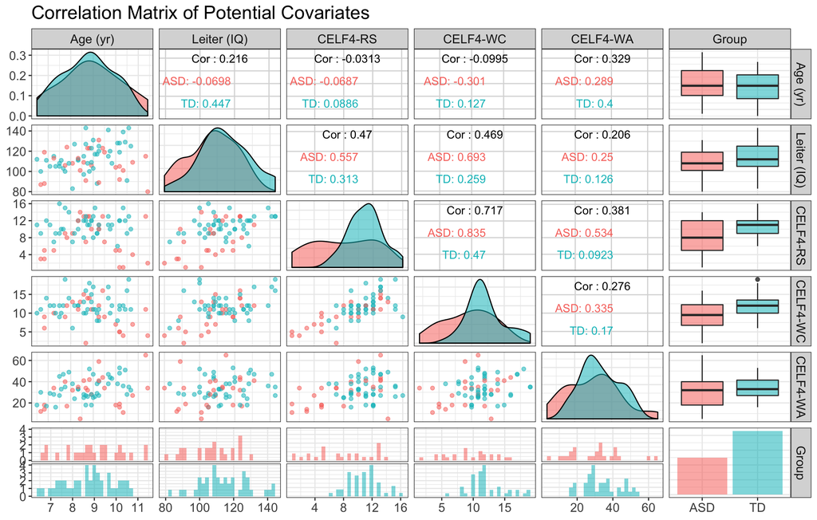

CELF-4-RS = CELF-4 Recalling Sentences (scaled scores); CELF-4-WC = CELF-4 Word Classes (scaled scores) and CELF-4-WA = CELF-4 Word Associations (raw scores, because no normative data is provided). The density plots arranged diagonally and the histograms at the bottom can be used to compare the distribution of scores in ASD and TD groups. The scatterplots and correlations on either side of the density plots can be used to examine the strength of the relation between variables both within and across groups. The boxplots and bar graphs on the right-hand side provide another way to compare distributions between groups.

```r
# create df with variables for the matrix
mtx <- df2 %>%
  select("age_yrs", "leiter_composite", "celf4_RS_scaled", "celf4_WC_total_scaled", "celf4_WA_total", "group") %>%
  rename("Age (yr)" = age_yrs, "Leiter (IQ)" = leiter_composite, "CELF4-RS" = celf4_RS_scaled,
         "CELF4-WC" = celf4_WC_total_scaled, "CELF4-WA" = celf4_WA_total, "Group" = group)

# age: years
# Leiter: Nonverbal IQ, composite score (normed: M = 100, SD = 15)
# CELF4 - RS: CELF-4 Recalling Sentences, scaled score (normed: M = 10, SD = 3)
# CELF4 - WC: CELF-4 Word Classes Total (Receptive and Expressive), scaled score (normed: M = 10, SD = 3)
# CELF4 - WA: CELF-4 Word Associations, total score
# create matrix plot
corr_mtx <- ggpairs(data = mtx,
        columns = 1:6,
        title = "Correlation Matrix of Potential Covariates",
        mapping = aes(colour = Group, alpha = 1),
        axisLabels = "show") +
        theme(text= element_text(size = 15))

# print and save plot
corr_mtx
```

```r
ggsave("./plots/corr_mtx.pdf", height = 8, width = 11, units = "in")
```

Taken together, the above matrix indicated that matching on all variables of age, nonverbal IQ, and the three language measures would likely result in less than half of our sample of children with ASD to be matched to a group with TD children. To retain as many children with ASD as possible, we matched on age and nonverbal IQ because both children with ASD and TD children were similarly distributed on these measures and both covariates have demonstrated relations with our primary experimental manipulation: how children learn using referential gaze. The choice of two covariates followed the guidelines by Blackford (2007), who suggests an approximate ratio of 5-10 participants per covariate.

Though one of our outcomes measures of interest was word learning, and children with stronger language abilities have been shown to have better performance on word learning tasks, we concluded that the overarching goal was to examine how children use referential gaze to learn in two different contexts (word learning and action understanding).

Additionally, our experimental manipulation tested how children with ASD treated referential gaze in contrast to an arrow cue, and there was no theoretical or evidence-based rationale suggesting that having stronger language abilities meant that children would learn better with one cue vs. another (or the contrary, that weaker language abilities meant that children would learn worse with one cue versus another). Thus, we reasoned that regardless of language ability, it was still possible to test whether children learned new words differently with a referential gaze cue vs. an arrow cue.

Another bonus of including all children with ASD was that the sample would reflect part of the heterogeneity seen in language abilities (keeping in mind that our sample was selected to have nonverbal IQ in the normal range, and therefore does not represent a full range of language abilities). We decided to further investigate the role of language ability on our experimental measures as a part of our exploratory analyses.

# Step 3: Conduct matching

**We used the MatchIt package (Ho et al., 2011) in R version 3.6.1 (R Core Team, 2019) to apply both the nearest neighbor and optimal matching methods.**

Both methods resulted in the same 25 TD children chosen as matches to the 25 children with ASD.

As seen in Table 2, nonverbal IQ is significantly higher in the TD group (n = 43) than in the ASD group (n = 25; p = .039), although on age both groups share similar means and standard deviations (p = .570). Thus, our next step was to select participants such that groups were balanced on both age and nonverbal IQ.

### Examine descriptive statistics of age and IQ before matching

```r
# subset only age and IQ
df2_age_IQ <- df2 %>%
  select(group, age_yrs, leiter_composite)

# compare groups
df2_age_IQ_compare <- compareGroups(group ~ age_yrs + leiter_composite , data = df2_age_IQ)
df2_age_IQ_compare_tbl <- createTable(df2_age_IQ_compare, digits = 2, type = 1, show.n = TRUE)
print(df2_age_IQ_compare_tbl, header.labels = c(p.overall = "p-value"))
```

```
##
## --------Summary descriptives table by 'group'---------
##
## _________________________________________________________
##                       ASD             TD       p-value N
##                       N=25           N=43
## ¯¯¯¯¯¯¯¯¯¯¯¯¯¯¯¯¯¯¯¯¯¯¯¯¯¯¯¯¯¯¯¯¯¯¯¯¯¯¯¯¯¯¯¯¯¯¯¯¯¯¯¯¯¯¯¯¯
## age_yrs           8.93 (1.34)    8.75 (1.14)    0.570  68
## leiter_composite 107.16 (13.61) 114.53 (14.18)  0.039  68
## ¯¯¯¯¯¯¯¯¯¯¯¯¯¯¯¯¯¯¯¯¯¯¯¯¯¯¯¯¯¯¯¯¯¯¯¯¯¯¯¯¯¯¯¯¯¯¯¯¯¯¯¯¯¯¯¯¯
```

### Create dataframe with covariates to be used for propensity scores

```r
# create df
df_ps_n68 <- df2 %>%
  select(participant, group, age_yrs, leiter_composite) %>%
  mutate(group.int = ifelse(group == "ASD", 1, 0)) # group must be an integer for MatchIt
```

### Conduct Nearest neighbor algorithm: n = 68

```r
# apply matching
m_near_n68 <- matchit(group.int ~ age_yrs + leiter_composite,
                     data = df_ps_n68, method = "nearest")

# get df of matched participants and associated covariates
m_near_n68_df <- match.data(m_near_n68)
head(m_near_n68_df)
```

```
##   participant group age_yrs leiter_composite group.int  distance weights
## 1         302   ASD    8.83              123         1 0.2575106       1
## 2         304   ASD    8.75              123         1 0.2539244       1
## 3         306   ASD   10.00              104         1 0.5088229       1
## 5         310   ASD    9.50              119         1 0.3254607       1
## 7         312   ASD   10.75              109         1 0.4991269       1
## 9         314   ASD   10.17               92         1 0.6439131       1
```

### Conduct Optimal matching algorithm: n = 68

```r
# apply matching
m_opt_n68 <- matchit(group.int ~ age_yrs + leiter_composite,
                     data = df_ps_n68, method = "optimal")

# get df of matched participants and associated covariates
m_opt_n68_df <- match.data(m_opt_n68)
head(m_opt_n68_df)
```

```
##   participant group age_yrs leiter_composite group.int  distance weights
## 1         302   ASD    8.83              123         1 0.2575106       1
## 2         304   ASD    8.75              123         1 0.2539244       1
## 3         306   ASD   10.00              104         1 0.5088229       1
## 5         310   ASD    9.50              119         1 0.3254607       1
## 7         312   ASD   10.75              109         1 0.4991269       1
## 9         314   ASD   10.17               92         1 0.6439131       1
##   subclass
## 1        1
## 2       22
## 3       25
## 5       10
## 7       17
## 9       18
```

### Compare participants selected with nearest neighbor vs. optimal matching: n = 68

This side-by-side comparison demonstrates that with nearest neighbor and optimal matching methods, the same set of 25 TD children were chosen as matches to the 25 children with ASD.

```r
# create dfs of ASD and TD participants selected from nearest neighbor and optimal matching methods
# English = 300 series
# French = 400 series
# ASD participants = even numbers
# TD participants = odd numbers
m_near_n68_part <- m_near_n68_df %>%
  dplyr::select(c(participant, group)) %>%
  rename(m_near_participants = participant,
         m_near_group = group) %>%
  arrange(m_near_group)
m_opt_n68_part <- m_opt_n68_df  %>%
  dplyr::select(c(participant, group)) %>%
  rename(m_opt_participants = participant,
         m_opt_group = group) %>%
  arrange(m_opt_group)

# compare participants selected from nearest neighbor vs. optimal matching methods
check_n68_df <- cbind(m_near_n68_part, m_opt_n68_part)
check_n68_df
```

```
##    m_near_participants m_near_group m_opt_participants m_opt_group
## 1                  302          ASD                302         ASD
## 2                  304          ASD                304         ASD
## 3                  306          ASD                306         ASD
## 4                  310          ASD                310         ASD
## 5                  312          ASD                312         ASD
## 6                  314          ASD                314         ASD
## 7                  318          ASD                318         ASD
## 8                  322          ASD                322         ASD
## 9                  324          ASD                324         ASD
## 10                 326          ASD                326         ASD
## 11                 330          ASD                330         ASD
## 12                 332          ASD                332         ASD
## 13                 402          ASD                402         ASD
## 14                 404          ASD                404         ASD
```

[output cut: 36 more lines]

# Step 4: Diagnose matching

We used visual inspection and statistics to examine how well groups were matched on their propensity scores. As seen in the figure below, visual inspection of propensity score plots depicted the same ASD participant with a high propensity score (Matched Treatment Units; this participant has a propensity score of approximately 0.8) without a close match among the selected matches in the TD group (Matched Control Units).

We next examined matching of propensity scores based on cut-off values proposed in the literature: a maximum standardized mean difference (*d*) of approximately .25, and variance ratios (vr) within the range of .5 to 2. The *d* value was close to the maximum of .25, although the vr was within the acceptable range (*d* = .24, vr = 1.46). Given the high standardized mean difference and the outlier seen in the propensity score plot, we removed the outlier ASD participant and conducted nearest neighbor and optimal matching methods with a revised sample of 24 children with ASD and 43 TD children.

### Propensity scores distribution

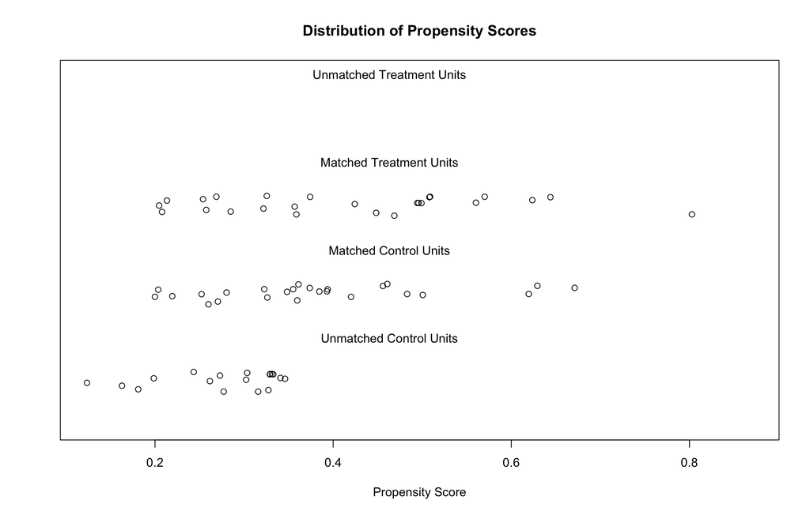

Matched Treatment Units = Children with ASD; Matched Control Units = selected matches of TD children; Unmatched Control Units = remaining unmatched TD children. Propensity scores calculated using the nearest neighbor and optimal matching methods resulted in the same values. This plot demonstrates the distribution of propensity scores when including covariates of age and IQ for all 25 children with ASD and 43 TD children. We see a similar distribution of propensity scores for Matched Treatment Units and Matched Control units, ranging from scores of 0.2 to above 0.6. Among the Matched Treatment Units, there appears to be one outlier where a child with ASD was assigned a propensity score of approximately 0.8.

```r
# nearest neighbor (the same participant is identified using the optimal matching method)
plot(m_near_n68, type = "jitter", interactive = F)
```

```r
# participant with high propensity score in ASD group
m_near_n68_df %>% filter(distance > .7)
```

```
##   participant group age_yrs leiter_composite group.int  distance weights
## 1         330   ASD   11.42               80         1 0.8027958       1
```

### Calculate standardized mean differences and variance ratios

```r
# NOTE: both nearest neighbor and optimal matching methods have the same participants, so either method will provide the same scores. Scores from both methods are presented here for clarity.
# nearest neighbor
# a) create vectors with data in asd and td group
near_asd_n68 <- m_near_n68_df %>%
  filter(group == "ASD")

near_td_n68 <- m_near_n68_df %>%
  filter(group == "TD")

# b) standardized mean difference of propensity score
# (Mtreatment - Mcontrol) / SDtreatment; (Stuart, 2010; Rubin, 2001; Rosenbaum & Rubin, 1985 - The American Statistician)
(mean(near_asd_n68$distance) - mean(near_td_n68$distance)) / sd(near_asd_n68$distance)
```

```
## [1] 0.2410058
```

```r
# c) variance ratio
(sd(near_asd_n68$distance)^2) / (sd(near_td_n68$distance)^2)
```

```
## [1] 1.456683
```

```r
# optimal matching
# a) create vectors with data in asd and td group
opt_asd_n68 <- m_opt_n68_df %>%
  filter(group == "ASD")

opt_td_n68 <- m_opt_n68_df %>%
  filter(group == "TD")

# b) standardized mean difference of propensity score
(mean(opt_asd_n68$distance) - mean(opt_td_n68$distance)) / sd(opt_asd_n68$distance)
```

```
## [1] 0.2410058
```

```r
# c) variance ratio
(sd(opt_asd_n68$distance)^2) / (sd(opt_td_n68$distance)^2)
```

```
## [1] 1.456683
```